# Functional load and sound change

This R Notebook contains a walk-through of my work to predict sound changes. For a written version, see Chapter 3 of [my dissertation](http://andreaceolin.eu/Functionalism_Lexical_Contrast.pdf).

## 1. Introduction

There is a long-term debate in Historical Linguistics on whether sound change can be predicted given the distribution of the sounds in the lexicon. The **Functional Load Hypothesis** [(King 1967)](https://www.jstor.org/stable/pdf/411969.pdf) states that the likelihood of a neutralization (aka merger) between two sounds is (inversely) proportional to how their contrast is *important* in a language.

The functional load of a sound pair can be measured by counting the number of word pairs whose distinction relies on that contrast (aka minimal pairs), or by using other measures of informativity, like [entropy loss](http://people.cs.uchicago.edu/~dinoj/fload_bookchapter.pdf).

In my work, I collected a dataset of mergers in different languages to investigate the hypothesis, using corpora from [CHILDES](https://childes.talkbank.org), [CELEX](http://celex.mpi.nl) and other public repositories. I present an analysis of the dataset here, using the R libraries **tidyverse** and **lme4**.

## 2. The dataset

Here is a quick look at the dataset.

```r
library(tidyverse)
data = read_csv('fl_data.csv')
head(data)
```

| Pair | Language | Type | Merged | Environment | MinPairs | EntropyLoss | Freq1 | Freq2 |
| --- | --- | --- | --- | --- | --- | --- | --- | --- |
| ai-oi | English(UK) | English_ai | 1 | Unconditioned | 7 | 5 | 414 | 45 |
| ai-ei | English(UK) | English_ai | 0 | Unconditioned | 63 | 35 | 414 | 471 |
| ai-au | English(UK) | English_ai | 0 | Unconditioned | 19 | 26 | 414 | 134 |
| ai-i: | English(UK) | English_ai | 0 | Unconditioned | 76 | 47 | 414 | 397 |
| I$-E$ | English(UK) | English_rhotic | 1 | Conditioned | 22 | 15 | 78 | 89 |
| $:-$$ | English(UK) | English_rhotic | 1 | Conditioned | 14 | 10 | 166 | 89 |

There are 116 entries for which the following information is available:

1. **Pair**: the pair of sounds being observed
2. **Language**: the language in which the pair is found
3. **Type**: this is a name used to refer to the merger class
4. **Merged**: binary variable distinguishing pairs for which a merger is attested in at least one variety of the language (‘1’) versus pairs for which no merger is reported (‘0’)
5. **Enrivonment**: it encodes whether the merger happens across the board (‘Unconditioned’) or is conditioned on a specific phonetic enrivonment (‘Conditioned’)
6. **MinPairs**: amount of minimal pairs found in the conversational corpora examined associated to the pair
7. **EntropyLoss**: entropy loss expected in the language after the merger occurs (multiplied by 1000)
8. **Freq1**: frequency of the first sound of the pair
9. **Freq2**: frequency of the second sound of the pair

A first question we want to ask is whether minimal pairs and entropy loss are predictors of mergers.

## 3. Transformations

Before proceeding with the analysis, we log-transform the variables of interest.

1. **LogMinPairs**: log-transformed `MinPairs`
2. **LogEntropyLoss**: log-transformed `EntropyLoss`

```r
data <- data %>%
  group_by(Type) %>%
  mutate(LogMinPairs=log(MinPairs+1)) %>%
  mutate(LogEntropyLoss=log(EntropyLoss+1))
```

## 4. Analysis

### 4.1 Logistic Regression

A simple way of testing functional load is seeing whether minimal pairs or entropy loss are predictors of mergers. [Wedel et al. (2013)](https://pubmed.ncbi.nlm.nih.gov/23685207/) propose to use a mixed-effect logistic regression model with minimal pairs and entropy loss as fixed effects, and merger type as a random effect, in order to account for the fact that different merger types can yield different numbers of minimal pairs and entropy (for instance, vowel and consonant mergers are expected to behave differently). We can replicate their analysis by using the `glmer()` function in the **lme4** library.

#### 4.1.1 Minimal Pairs

We can visualize the relationship between minimal pairs and mergers using a boxplot through **ggplot2**.

First, we create a categorical version of the dependent variable for visualization purposes.

```r
data <- data %>%
  mutate(Merged_categorical=ifelse(Merged, 'Merged', 'Unmerged'))
```

Then, we use a boxplot to compare, for each merger set, the number of minimal pairs associated to actual mergers versus unmerged pairs. The graph shows us indeed that the number of minimal pairs for mergers is lower, on average, than that for sound pairs that do not merge.

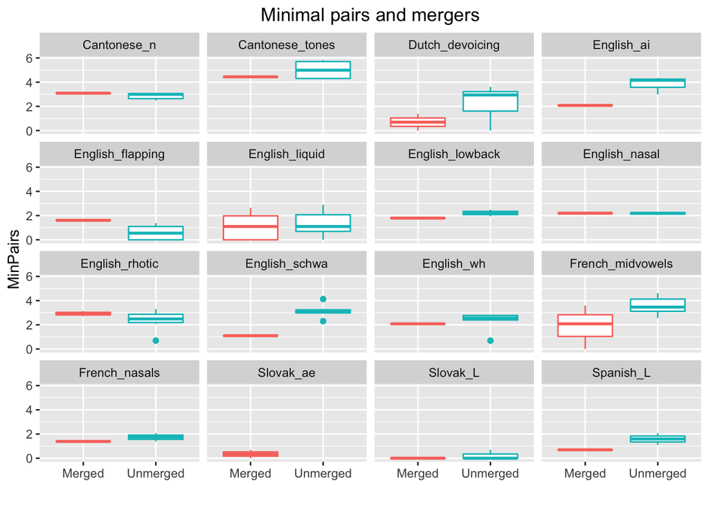

```r
ggplot(data, aes(x=Merged_categorical,y=LogMinPairs, color=Merged_categorical))+
  geom_boxplot(show.legend=FALSE) +
  facet_wrap(~Type) +
  labs(title="Minimal pairs and mergers", x ="", y = "MinPairs") +
  theme(plot.title = element_text(hjust = 0.5))
```

The result is confirmed by the logistic regression analysis:

```r
library(lme4)
m1 = glmer(Merged ~ LogMinPairs + (1|Type), family=binomial, data=data)
summary(m1)
```

```
## Generalized linear mixed model fit by maximum likelihood (Laplace
##   Approximation) [glmerMod]
##  Family: binomial  ( logit )
## Formula: Merged ~ LogMinPairs + (1 | Type)
##    Data: data
##
##      AIC      BIC   logLik deviance df.resid
##    127.4    135.6    -60.7    121.4      113
##
## Scaled residuals:
##     Min      1Q  Median      3Q     Max
## -0.8494 -0.5998 -0.4469 -0.2476  3.0763
##
## Random effects:
##  Groups Name        Variance Std.Dev.
##  Type   (Intercept) 0        0
## Number of obs: 116, groups:  Type, 16
##
## Fixed effects:
##             Estimate Std. Error z value Pr(>|z|)
## (Intercept)  -0.3265     0.3688  -0.885   0.3760
## LogMinPairs  -0.4324     0.1725  -2.506   0.0122 *
## ---
## Signif. codes:  0 '***' 0.001 '**' 0.01 '*' 0.05 '.' 0.1 ' ' 1
##
## Correlation of Fixed Effects:
##             (Intr)
## LogMinPairs -0.795
```

The number of minimal pairs turns out to be slightly significant, with `z=-2.506` and `p=0.0122`. The minus sign is also correct: the presence of minimal pairs *inhibits* mergers.

#### 4.1.2 Entropy

At first sight, the graph seems to be similar for entropy, even though there are several case where entropy is actually higher for the sound pairs for which a merger is attested:

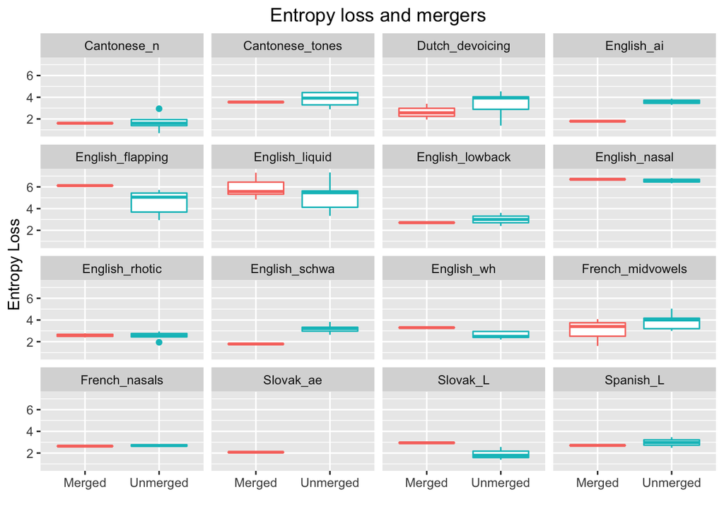

```r
ggplot(data, aes(x=Merged_categorical, LogEntropyLoss, color=Merged_categorical)) +
  geom_boxplot(show.legend=FALSE) +
  facet_wrap(~Type) +
  labs(title="Entropy loss and mergers", x ="", y = "Entropy Loss") +
  theme(plot.title = element_text(hjust = 0.5))
```

In fact, if we run a logistic regression analysis, the effect is not significant: we have `z=-0.048` and `p=0.9619`.

```r
m2 = glmer(Merged ~ LogEntropyLoss + (1|Type), family=binomial, data=data)
summary(m2)
```

```
## Generalized linear mixed model fit by maximum likelihood (Laplace
##   Approximation) [glmerMod]
##  Family: binomial  ( logit )
## Formula: Merged ~ LogEntropyLoss + (1 | Type)
##    Data: data
##
##      AIC      BIC   logLik deviance df.resid
##    134.2    142.5    -64.1    128.2      113
##
## Scaled residuals:
##     Min      1Q  Median      3Q     Max
## -0.5700 -0.5656 -0.5635 -0.5574  1.7952
##
## Random effects:
##  Groups Name        Variance Std.Dev.
##  Type   (Intercept) 0        0
## Number of obs: 116, groups:  Type, 16
##
## Fixed effects:
##                 Estimate Std. Error z value Pr(>|z|)
## (Intercept)    -1.119403   0.580506  -1.928   0.0538 .
## LogEntropyLoss -0.006949   0.145586  -0.048   0.9619
## ---
## Signif. codes:  0 '***' 0.001 '**' 0.01 '*' 0.05 '.' 0.1 ' ' 1
##
## Correlation of Fixed Effects:
##             (Intr)
## LgEntrpyLss -0.928
```

### 4.2 Conditioned and Unconditioned mergers

#### 4.2.1 Unconditioned mergers

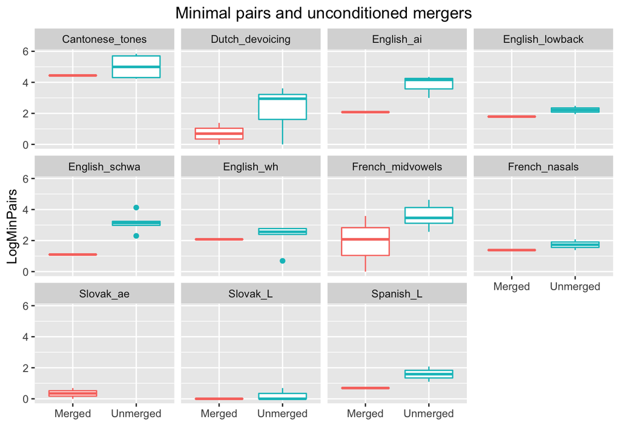

```r
unconditioned = data %>%
  filter(Environment == 'Unconditioned')

ggplot(unconditioned, aes(x=Merged_categorical,y=LogMinPairs,color=Merged_categorical))+
  geom_boxplot(show.legend=FALSE) +
  facet_wrap(~Type) +
  labs(title="Minimal pairs and unconditioned mergers", x ="", y = "LogMinPairs") +
  theme(plot.title = element_text(hjust = 0.5))
```

Almost all the cases seem to show a functional load effect.

This result is confirmed by the fact that in spite of the reduced sample size, the mixed-effect model shows that the `LogMinPairs` coefficient is still significant:

```r
m3 = glmer(Merged ~ LogMinPairs + (1|Type), family=binomial, data=unconditioned)
summary(m3)
```

```
## Generalized linear mixed model fit by maximum likelihood (Laplace
##   Approximation) [glmerMod]
##  Family: binomial  ( logit )
## Formula: Merged ~ LogMinPairs + (1 | Type)
##    Data: unconditioned
##
##      AIC      BIC   logLik deviance df.resid
##     66.6     73.2    -30.3     60.6       63
##
## Scaled residuals:
##     Min      1Q  Median      3Q     Max
## -1.2767 -0.4791 -0.3541 -0.1323  4.4566
##
## Random effects:
##  Groups Name        Variance Std.Dev.
##  Type   (Intercept) 0        0
## Number of obs: 66, groups:  Type, 11
##
## Fixed effects:
##             Estimate Std. Error z value Pr(>|z|)
## (Intercept)   0.4886     0.5446   0.897  0.36967
## LogMinPairs  -0.7827     0.2485  -3.150  0.00163 **
## ---
## Signif. codes:  0 '***' 0.001 '**' 0.01 '*' 0.05 '.' 0.1 ' ' 1
##
## Correlation of Fixed Effects:
##             (Intr)
## LogMinPairs -0.810
```

Even though the statistical power is reduced, the number of minimal pairs is even *more* significant than our previous analysis! We have `z=-3.150` and `p=0.00163`.

#### 4.2.2 Conditioned mergers

Conversely, a look at the conditioned mergers reveals that none of them show functional load effects when looking at minimal pairs:

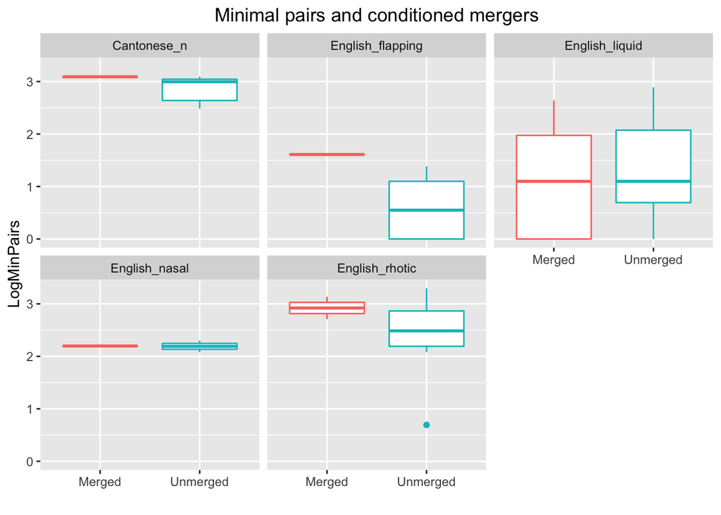

```r
conditioned = data %>%
  filter(Environment == 'Conditioned')

ggplot(conditioned, aes(x=Merged_categorical,y=LogMinPairs, color=Merged_categorical))+
  geom_boxplot(show.legend=FALSE) +
  facet_wrap(~Type) +
  labs(title="Minimal pairs and conditioned mergers", x ="", y = "LogMinPairs") +
  theme(plot.title = element_text(hjust = 0.5))
```

This is confirmed by the statistical analysis, for which the `LogMinPairs` coefficient becomes not significant, and is also associated to the opposite sign, which means that, if anything, we are having an *anti-functional load* effect!

```r
m4 = glmer(Merged ~ LogMinPairs + (1|Type), family=binomial, data=conditioned)
summary(m4)
```

```
## Generalized linear mixed model fit by maximum likelihood (Laplace
##   Approximation) [glmerMod]
##  Family: binomial  ( logit )
## Formula: Merged ~ LogMinPairs + (1 | Type)
##    Data: conditioned
##
##      AIC      BIC   logLik deviance df.resid
##     61.0     66.8    -27.5     55.0       47
##
## Scaled residuals:
##     Min      1Q  Median      3Q     Max
## -0.6030 -0.5796 -0.5488 -0.5236  1.9099
##
## Random effects:
##  Groups Name        Variance Std.Dev.
##  Type   (Intercept) 0        0
## Number of obs: 50, groups:  Type, 5
##
## Fixed effects:
##             Estimate Std. Error z value Pr(>|z|)
## (Intercept) -1.29413    0.60577  -2.136   0.0327 *
## LogMinPairs  0.08568    0.30220   0.284   0.7768
## ---
## Signif. codes:  0 '***' 0.001 '**' 0.01 '*' 0.05 '.' 0.1 ' ' 1
##
## Correlation of Fixed Effects:
##             (Intr)
## LogMinPairs -0.837
```

## 5. Conclusions

The analysis shows that functional load is a factor in sound change, but only when the sound changes are **unconditioned**. If the sound change neutralizes a contrast only in a specific environment, functional load does not seem to be a relevant factor. This finding has important consequences for sound change, but also for language acquisition.

For more information on the topic, check [my dissertation](http://andreaceolin.eu/Functionalism_Lexical_Contrast.pdf), or this [summary article](https://repository.upenn.edu/pwpl/vol26/iss2/6/) that appeared on PWPL.